# Untitled

Tyler Lawrence

2023-11-27

# Billionaire Data:

This is today I will be using some billionaire data from this year I found on Kaggle, at https://www.kaggle.com/datasets/nelgiriyewithana/billionaires-statistics-dataset.

# Questions to answer:

- What is the difference between the genders when it comes to wealth?
- How does wealth scale with age?
- Which industries make the most money?

# Some code for you

billionares <- read.csv(“Billionaires Statistics Dataset.csv”) usBills <- billionares %>% filter(country == “United States” & rank <= 500) %>% mutate(usRank = as.integer(rank(-finalWorth))) %>% select(usRank, finalWorth, category, personName, country, source, status, gender, birthYear)

# Let’s start with a comparison of the representation of genders.

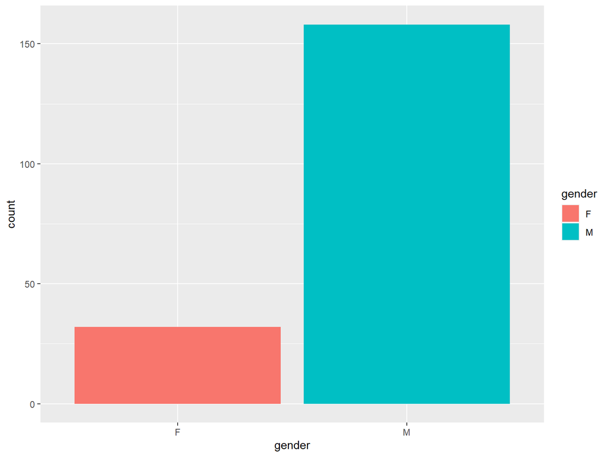

## Not looking good! As you can see, the distribution of wealth between the sexes is a little uneven!

But that’s just the amount of people, how much does the average female billionaire make compared to the average male billionaire?

# Mean of wealth of the males and females:

```
## # A tibble: 2 × 2
##   gender `mean(finalWorth)`
##   <chr>               <dbl>
## 1 F                  13709.
## 2 M                  17128.
```

Not as bad as it could be, but not very good either.

# Here’s the density by rank of the sexes

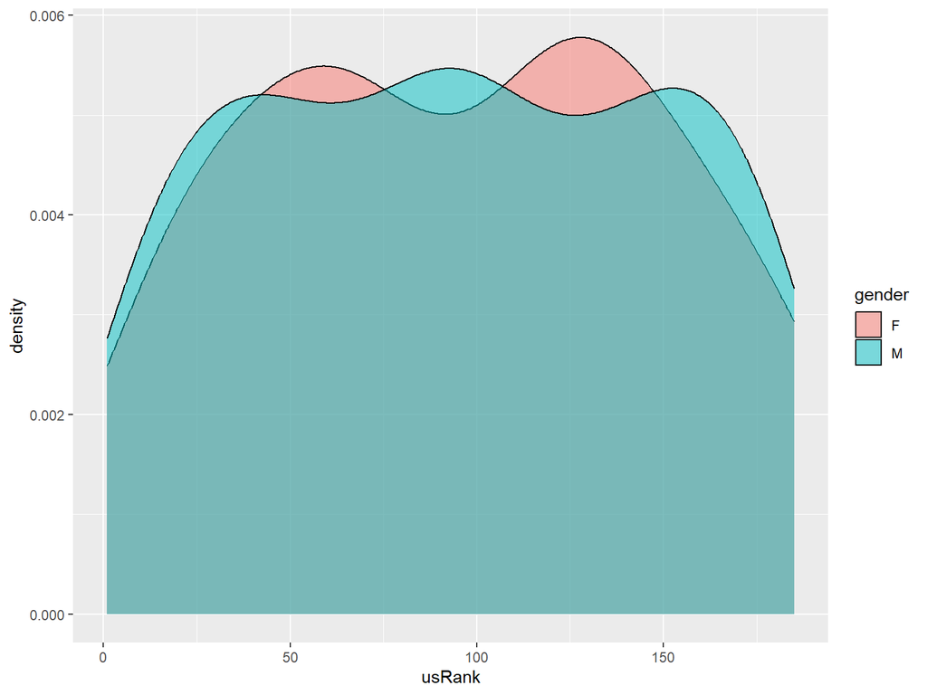

# Now that I’ve shown the sexism in the American Capitalist system, how about we show how age affects wealth?

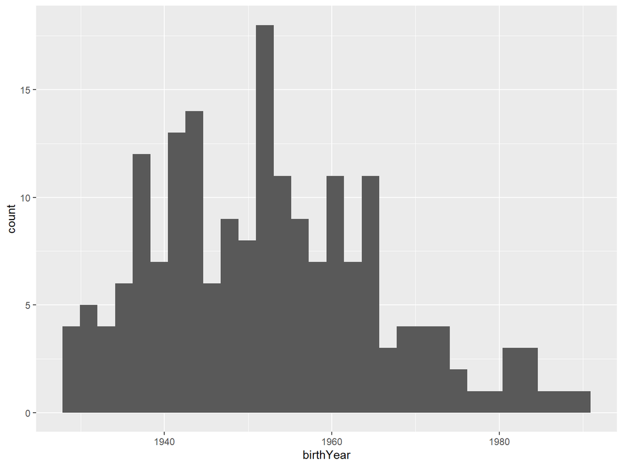

That’s not great either!

# Now how do certain industries compare to others?

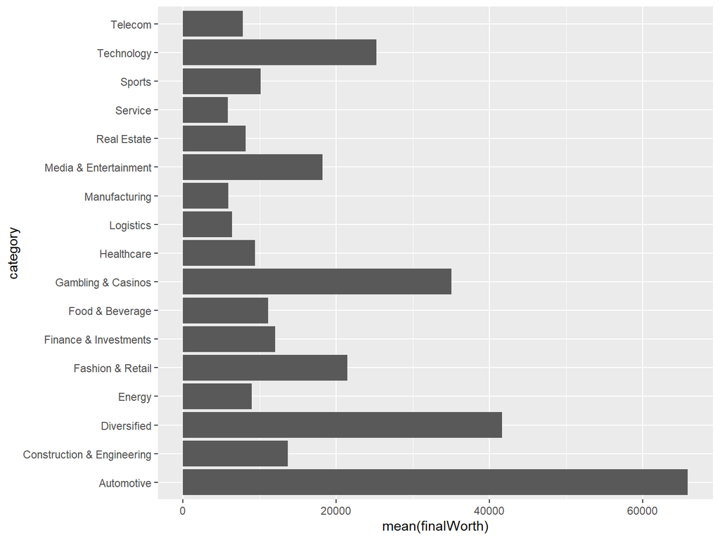

As we can see, the automotive industry dominates against all other industries, however, this might be mostly because of Elon Musk, who is listed as only automotive.